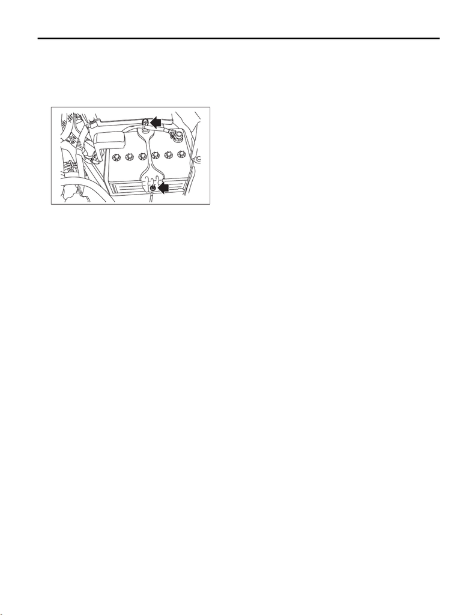

SC(STI)-21

Battery

STARTING/CHARGING SYSTEMS

4. Battery

A: REMOVAL

1) Disconnect the positive (+) terminal after disconnecting the negative (–) terminal of battery.

2) Remove the harness clip of the negative terminal from the battery rod.

3) Remove the flange nut from battery rod and remove battery holder.

4) Remove the battery.

B: INSTALLATION

Install in the reverse order of removal.

Tightening torque:

3.5 N·m (0.4 kgf-m, 2.6 ft-lb)

NOTE:

• Clean the battery cable terminals and apply grease to retard the formation of corrosion.

• Connect the positive (+) terminal, and then connect the negative (–) terminal of the battery.

• After the battery is installed, initial diagnosis of the electronic throttle control is performed. Wait for 10 sec-

onds or more after turning the ignition switch to ON, and then start the engine.

C: INSPECTION

WARNING:

• As batteries produce flammable gases, be careful not to bring an open flame close to the batteries.

• Ventilate sufficiently when using or charging battery in enclosed space.

• Electrolyte is corrosive acid, and has toxicity; be careful of handling the fluid.

• For safety, in case an explosion does occur, wear eye protection or shield your eyes when working

near any battery. In addition, never lean over the battery.

• Be careful that the electrode does not come into contact with skin, eyes or clothing. Especially at

contact with eyes, flush with water for 15 minutes and get prompt medical attention.

• Be careful not to let the electrode contact with the coated parts.

• Before starting work, remove rings, metal watch-bands, and other metal jewelry.

• Be careful not to let the metal tools contact the positive battery terminal and anything connected

to it. When the operation using a metal tool to the positive terminal or anything connected to it is re-

quired, disconnect the battery ground terminal before starting the operation.

1. APPEARANCE

Check the battery case, top cover, vent plugs, and terminal posts for dirt or cracks.

NOTE:

If necessary, clean with water and wipe with a dry cloth. Apply a thin coat of grease on the terminal posts to

prevent corrosion.

Check

•Normal

→

Go to the check item 2.

• Abnormal

→

Replace the battery.

SC-02238

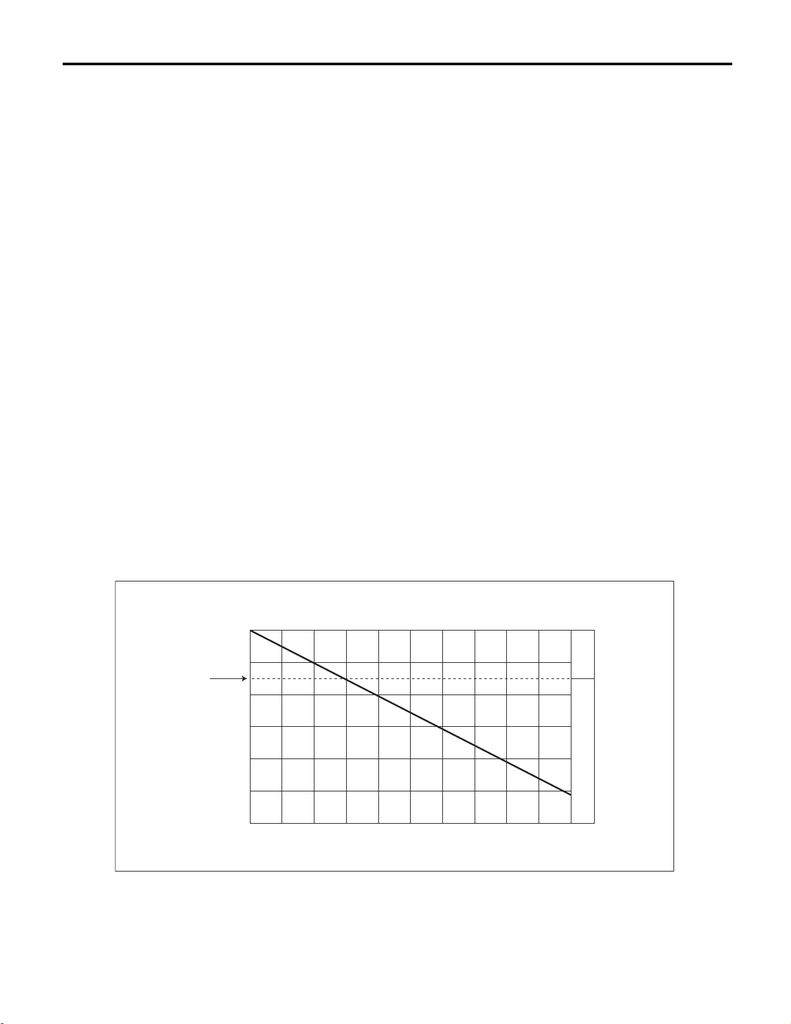

SC(STI)-22

Battery

STARTING/CHARGING SYSTEMS

2. ELECTROLYTE LEVEL

Check the electrolyte level in each cell.

CAUTION:

Do not fill beyond MAX level.

NOTE:

If the level is below the middle point between MIN level and MAX level, pour distilled water into the battery

cell to bring the level to MAX.

Check

• MAX level

→

Go to the check item 3.

• Below the middle point between MIN level and MAX level

→

Fill

→

Go to the check item 3.

3. SPECIFIC GRAVITY OF ELECTROLYTE

Check the specific gravity of the electrolyte using a hydrometer and a thermometer.

NOTE:

• Specific gravity varies with temperature of electrolyte so that it must be corrected at 20°C (68°F) using the

following calculation:

20

= St + 0.0007 × (t – 20)

S

20

: Specific gravity corrected at electrolyte temperature of 20°C

St: Measured specific gravity

t: Measured temperature (°C)

• When measuring in a simplified manner using the battery terminal voltage, calculate the specific gravity by

the following formula.

Perform the steps 1) and 2) before measuring the voltage in order to stabilize the voltage.

1) Turn the ignition switch to OFF and illuminate the headlight for 30 seconds.

2) After turning off the headlight, leave the vehicle for one minute.

Specific gravity = [ 0.187 × battery terminal voltage (V) ] – 1.1

• Measuring the specific gravity of the electrolyte in the battery will disclose the state of charge of the battery.

The relation between specific gravity and state of charge is as shown in the figure.

(A) Specific gravity [20°C (68°F)] (B) Amount of discharge (%) (C) Good

(D) Need to charge or replace

SC-03068

0

1.12

1.20

1.16

1.24

1.28

1.22

1.08

1.04

(A)

(B)

(C)

(D)

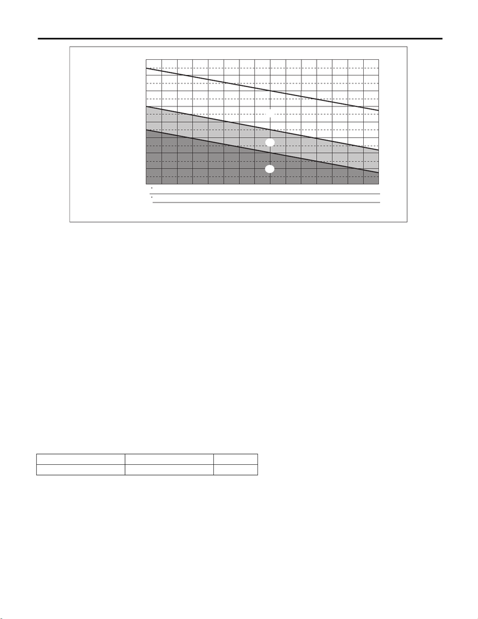

SC(STI)-23

Battery

STARTING/CHARGING SYSTEMS

Check

• Specific gravity: 1.250 — 1.290, and difference between cells is 0.04 or less

→

Battery is normal

• Specific gravity: Less than 1.250, or difference between cells is 0.04 or more

→

Battery needs to be

charged or replaced

D: CHARGE

WARNING:

• Do not bring an open flame close to the battery when working.

CAUTION:

• Prior to charging, corroded terminals should be cleaned with a brush and common caustic soda

solution.

• Be careful while charging the battery because it produces flammable gasses.

• Observe instructions when handling the battery charger.

• Before charging the battery on the vehicle, disconnect the battery ground terminal to prevent dam-

age of generator diodes or other electrical units.

1. NORMAL CHARGE (CONSTANT CURRENT CHARGE)

Charge the battery with the current value specified by manufacturer or with approximately 1/10 of battery’s

rating capacity. (See the table below.)

CAUTION:

• The charge control feature and specifications for judgment of charge completion depend on the

device. Follow the instruction manual of the charger used.

• Keep the electrolyte temperature at 45°C (113°F) or less while charging. Stop charging when the

temperature exceeds this value.

(A) Specific gravity [20°C (68°F)] (B) Electrolyte temperature (C) Good

(D) Caution (E) Need charging

Battery size Charging current (A) CCA (A)

55D23L 4.0 — 5.0 390

SC-02666

0

10

20

30

40

50

1.22

1.26

1.24

1.28

1.30

1.20

(A)

(B)

1.32

68

86

14

32

50

104

122

(E)

(D)

(C)

[figure not shown]

SC(STI)-24

Battery

STARTING/CHARGING SYSTEMS

NOTE:

The characteristics of typical charging methods are as follows.

• Constant current charging

This method makes it easy to charge to 100%, since the electrolyte is agitated by the gassing occurred at the

end of charging. However, the time for charging is comparatively long because the current value is kept con-

stant.

• Constant voltage charging

This method completes charging in a short period of time due to the large current. However, it is difficult to

charge to 100% because no gassing occurred at the end of charging and the electrolyte is not agitated.

Therefore, the combined use with the constant current charging is preferable.

• Quasi-constant voltage charging

This method is widely used for commercially available chargers.

Compared to the constant voltage charging whose charging current at the beginning of charging becomes

large, it reduces the charging current by lowering the voltage at the initial stage, resulting in battery load re-

duction. The time for charging is comparatively long. However, this type of chargers can be manufactured

comparatively inexpensive due to the simple control circuit (or manual settings). After the initial stage of

charging is completed, it gradually raises the charging voltage so that the charging current is within the spec-

ification, until the battery is fully charged.

• Constant voltage/current charging

In addition to the constant voltage charging, this method controls the upper limit of the current.

The constant current charging is applied at the beginning of charging, and the constant voltage charging is

applied at the end. This makes battery charge comparatively efficient in a short period of time. Charging by

generators is similar to this method.

Judgment of charge completion

1) Specific gravity of electrolyte should be held within the specific range of 1.250 — 1.290 for one hour or

more.

2) Voltage while charging should be held within the specified range of 15.0 — 16.8 V for one hour or more.

3) Gas is actively generated in all cells.

4) The amount of charge reaches 1.2 — 1.5 times of the amount of discharge.

NOTE:

The amount of discharge/charge can be calculated by the following formula.

Amount of discharge (Ah) = remaining capacity calculated by specific gravity (%) × 5 hour rate capacity (Ah)

Amount of charge (Ah) = charging current value (A) × time for charging

2. QUICK CHARGING

Quick charging is a method that the battery is charged in a short period of time with a relatively large current

by using a quick charger.

Charge the battery with the current value at approximately 1/2 of battery’s rating capacity. (See the table be-

low.)

CAUTION:

• Quick charging is accompanied by a large amount of heat generation. Charging should be com-

pleted in up to 30 minutes regardless of battery size.

• Quick charging is used to recover the battery until it can start the vehicle. For full charging, use the

normal charging method.

• Keep the electrolyte temperature at 55°C (131°F) or less while quick charging. Stop charging when

the temperature exceeds this value.

Battery size Charging current (A) CCA (A)

55D23L 20.0 — 25.0 390

[figure not shown]

ENGINE (DIAGNOSTICS)

EN(STI)(diag)

Page

1. Basic Diagnostic Procedure .......................................................................2

2. Check List for Interview ..............................................................................3

3. General Description ...................................................................................5

4. Electrical Component Location ..................................................................8

5. Engine Control Module (ECM) I/O Signal ................................................19

6. Engine Condition Data .............................................................................29

7. Data Link Connector ................................................................................30

8. General Scan Tool ...................................................................................31

9. Subaru Select Monitor ..............................................................................36

10. Read Diagnostic Trouble Code (DTC) .....................................................42

11. Inspection Mode .......................................................................................43

12. Drive Cycle ...............................................................................................49

13. Clear Memory Mode .................................................................................59

14. System Operation Check Mode ...............................................................60

15. Malfunction Indicator Light .......................................................................61

16. Diagnostics for Engine Starting Failure ....................................................67

17. Diagnostic Procedure for Subaru Select Monitor Communication ...........84

18. List of Diagnostic Trouble Code (DTC) ....................................................86

19. Diagnostic Procedure with Diagnostic Trouble Code (DTC) ....................96

20. Diagnostic Procedure without Diagnostic Trouble Code (DTC) .............426

21. General Diagnostic Table .......................................................................429